# SimiCviz: Visualization and Analysis of Gene Regulatory Networks

## 3.3 Filtering Options

Different GRN methods provide different quality metrics. Adjust filtering based on your method:

```r
# SimiC: Filter by adjusted R² (goodness of fit)

processor_simic <- AUCProcessor(
  weights = simic_weights,
  expression = expr_mat,
  cell_labels = cell_labels,
  adj_r2_list = adjusted_r_squared, # a list length as simic_weights
  qc_type = "adj_r2",
  qc_threshold = 0.7  # Keep targets with R² ≥ 0.7
)

# SCENIC / Pando: Filter by adjusted p-value
processor_scenic <- AUCProcessor(
  weights = weights_df,
  expression = expr_mat,
  cell_labels = cell_labels,
  qc_type = "p_value",
  qc_threshold = 0.05,  # Keep targets with adj_p_val ≤ 0.05
  n_cores = 4,
  backend = "multisession"
  )

# Compute with the same data, different parameters
processor_scenic <- compute_auc(processor_scenic, sort_by = "weight")
```

Once you have computed activity scores, let’s visualize the results!

# 4 Network Visualization

For visualization we need a `SimiCvizExperiment` object loaded with the results.

If you used `load_SimiCPipeline` of computed the activity scores with `calculate_activity_scores` you already have it.

```r
# Recall above examples
 simic_full # Complete SimiCpipeline output
## An object of class SimiCvizExperiment
##  4 label(s), 10 TF(s), 200 target(s)
##  Weights: 4 matrices [0: 10 x 200, 1: 10 x 200, 2: 10 x 200, 3: 10 x 200]
##  AUC: collected (3000 cells x 10 TFs)
##  Cell labels: 3000 cells across 4 label(s) [0, 1, 2, 3]
##  Label names: 0 = control, 1 = PD-L1, 2 = DAC, 3 = Combination
##  Colors: 0 = #e0e0e0, 1 = #a8c8ff, 2 = #ffb6b6, 3 = #c1a9e0
##  TFs: Pms1, Prrx2, Ets1, Tet2, Crebrf, Gli3, ...
##  Targets: Brinp3, Slit2, Top2a, Wls, Kif20b, Lamp2, ...
##  Meta keys: adjusted_r_squared, run_name, lambda1, lambda2
```

```r
 viz_obj_simic # SimiCPipeline weights -> `calculate_activity_scores`
## An object of class SimiCvizExperiment
##  4 label(s), 10 TF(s), 200 target(s)
##  Weights: 4 matrices [0: 10 x 200, 1: 10 x 200, 2: 10 x 200, 3: 10 x 200]
##  AUC: collected (3000 cells x 10 TFs)
##  Cell labels: 3000 cells across 4 label(s) [0, 1, 2, 3]
##  Label names: 0 = control, 1 = PD-L1, 2 = DAC, 3 = Combination
##  Colors: 0 = #e0e0e0, 1 = #a8c8ff, 2 = #ffb6b6, 3 = #c1a9e0
##  TFs: Pms1, Prrx2, Ets1, Tet2, Crebrf, Gli3, ...
##  Targets: Brinp3, Slit2, Top2a, Wls, Kif20b, Lamp2, ...
##  Meta keys: adjusted_r_squared
```

Otherwise you can load your results in `SimiCvizExperiment` as exemplified above including the activity scores results in the `auc` slot.

**Note**: Although activity score matrix is not strictly necessary, you need it to fully explore all the visualization tools of `SimiCviz`.

If you used other methods to calculate a cell specific activity score metrics with a different algorithm, you can import those as well in:

- wide format: cells x TF scores matrix
- long format: data. frame with cell, tf, score
- .pickle file (only for SimiC v1)

```r
# Create SimiCvizExperiment
simic <- SimiCvizExperiment(weights = simic_weights,
                             auc = auc_wide,
                             cell_labels = cell_labels,
                             label_names = c("control","PD-L1","DAC","Combination"),
                             colors = c("#e0e0e0", "#a8c8ff", "#ffb6b6", "#c1a9e0"))
## `weights` provided as a list.
## Cell labels file contains extra columns
## cell / category / label
## AUC in wide format (cells x TFs).
```

```r
simic
## An object of class SimiCvizExperiment
##  4 label(s), 10 TF(s), 200 target(s)
##  Weights: 4 matrices [0: 10 x 200, 1: 10 x 200, 2: 10 x 200, 3: 10 x 200]
##  AUC: collected (3000 cells x 10 TFs)
##  Cell labels: 3000 cells across 4 label(s) [0, 1, 2, 3]
##  Label names: 0 = control, 1 = PD-L1, 2 = DAC, 3 = Combination
##  Colors: 0 = #e0e0e0, 1 = #a8c8ff, 2 = #ffb6b6, 3 = #c1a9e0
##  TFs: Pms1, Prrx2, Ets1, Tet2, Crebrf, Gli3, ...
##  Targets: Brinp3, Slit2, Top2a, Wls, Kif20b, Lamp2, ...
```

After you created a `SimiCvizExperiment` object, we can use the plotting functions to visualize the results.

If you want to save your plots in pdf you can define figure output directory `out_dir = plot_dir`, change the `filename` and set the argument `save = TRUE`

```r
plot_dir <- file.path(getwd(),"SimiCviz_output")
dir.create(plot_dir,recursive = TRUE)
```

## 4.1 Quality Assessment (SimiC only)

To assess the goodness of SimiC’s fitted model of target expression we can plot the distribution adjusted R² values across all targets.

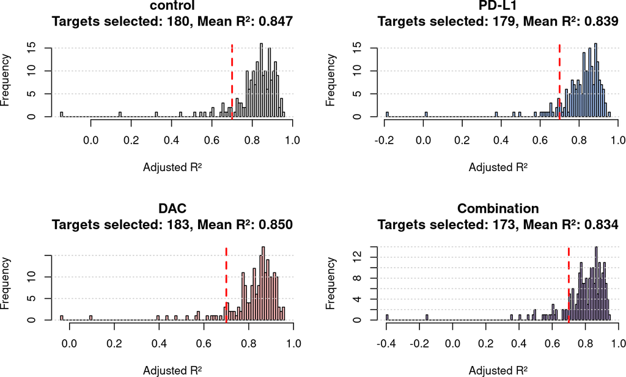

```r
# Plot distribution of adjusted R² values across targets
# Extract Adjusted R squared from SimiC outputs
out <- read_pickle(weights_file)
adjusted_r_squared <- out$adjusted_r_squared
plot_r2_distribution(adjusted_r_squared, simic, grid = c(2, 2),
                     save = FALSE, out_dir = plot_dir)
```

Here we can see that most of the R² values are over 0.7, indicating that the model explains a significant portion of the variance in the target gene expression.

Lower R² might indicate:

- Noisy data
- Missing regulatory interactions
- Complex regulation not captured by linear model

For these targets with low adjusted R2, we suggest to filter them out before plotting. We select a threshold of 0.7 as it was the same used to calculate the activity scores in SimiCPipeline and above. You can change this threshold as needed, but you should re-run the activity score calculation (or SimiCPipeline) with the same threshold to be consistent.

*If you already filtered your weight matrix before creating the SimiCviz obejct you can skip this part*

```r
# Select targets by adjusted R2
unselected_targets <- list()
selected_targets <- list()
lab_keys <- names(simic@label_names)
for (lab in lab_keys){
    # Save selected for plotting
    selected_targets[[lab]] <- simic@target_ids[which(adjusted_r_squared[[lab]] >= 0.7)]
    # Save unselected for reporting
    label <- simic@label_names[[lab]]
    unselected_targets[[label]] <- simic@target_ids[which(adjusted_r_squared[[lab]] < 0.7)]
}
print("Number of unselected targets per label:")
## [1] "Number of unselected targets per label:"
```

```r
print(sapply(unselected_targets, length))
##     control       PD-L1         DAC Combination
##          20          21          17          27
```

## 4.2 Weights Visualization

### 4.2.1 TF Barplots:

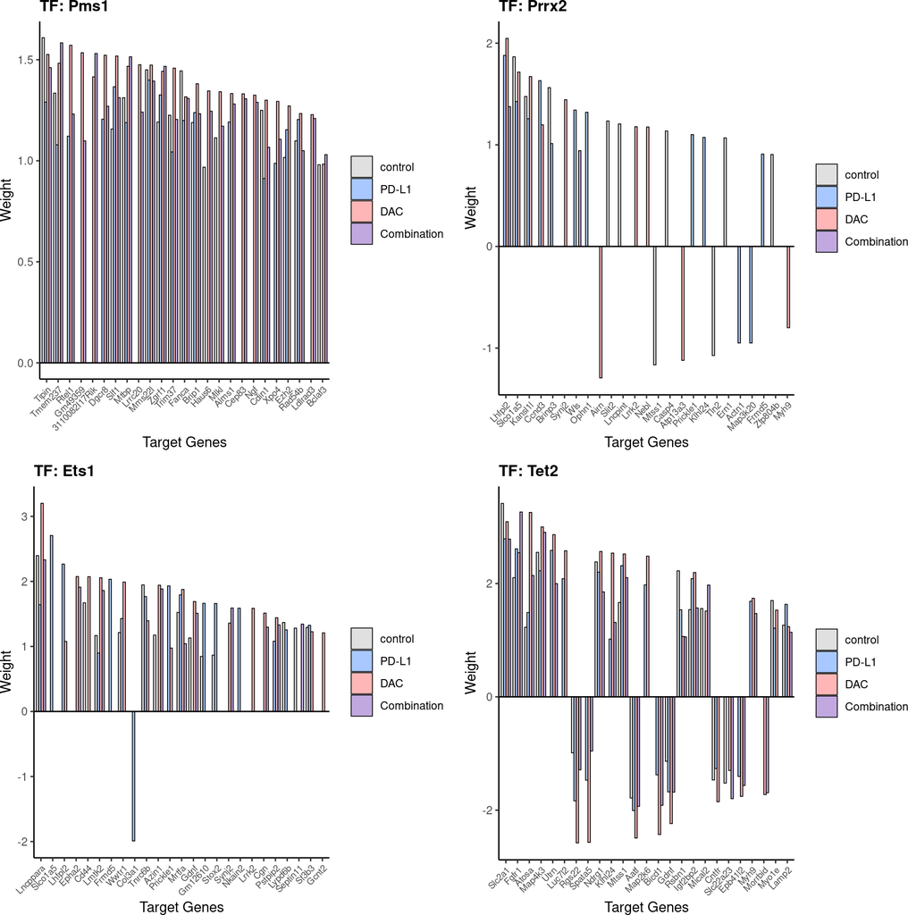

```r
plot_tf_weights(
  simic,
  tf_names = simic@tf_ids[1:4],
  top_n = 25,
  allowed_targets = selected_targets,  # Filter by R² if desired
  grid = c(2, 2),
  save = FALSE,
  out_dir = plot_dir,
  filename = "TF_weights_barplot.pdf"
)
## Plotting 4 TF weight barplot(s)...
```

### 4.2.2 Target Barplots:

Now we will plot the regulators of each target. This plot shows only the TFs with non-zero weights.

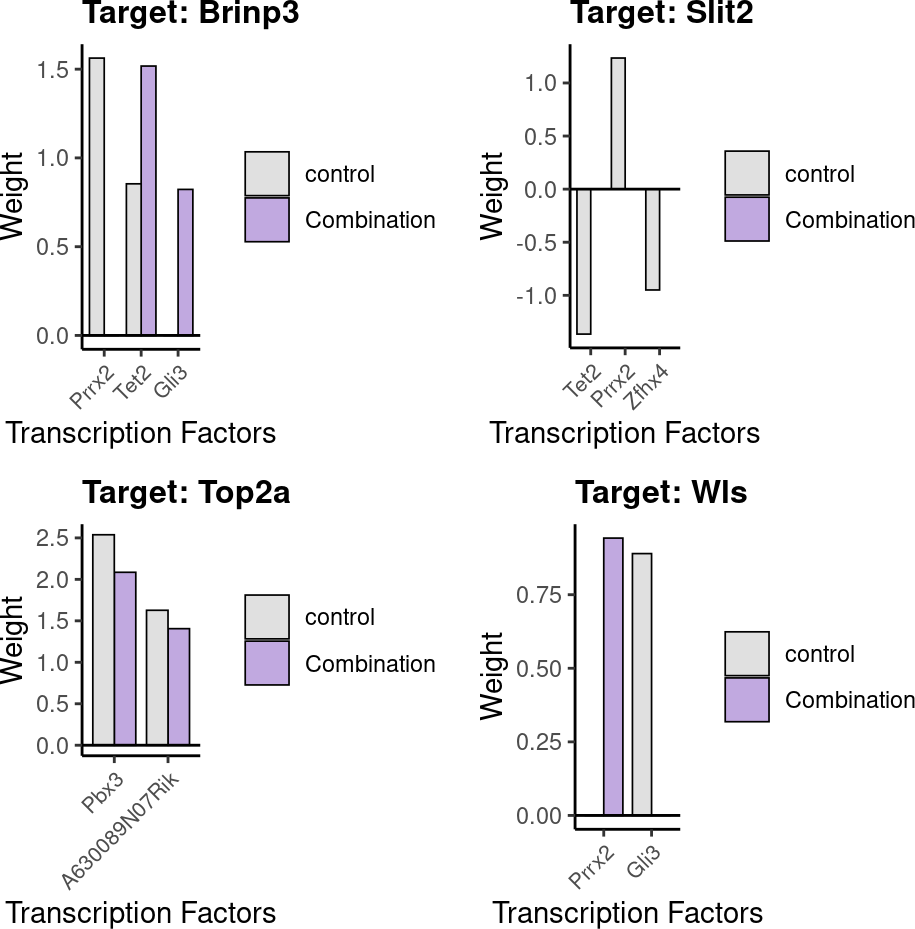

```r
plot_target_weights(
  simic,
  target_names = simic@target_ids[1:4],
  labels = c("control", "Combination"),
  grid = c(2, 2),
  save = FALSE,
  out_dir = plot_dir,
  filename = "Target_weights_barplot.pdf"
)
## Plotting 4 target weight barplot(s)...
```

**Note:** If you want to plot all TFs and Targets leave the `tf_names` and target_names arguments respectively blank. ***Note:**: You can also save teh output and acces indivicual plots

```r
all_tfs_barplots <- plot_tf_weights(
                          simic,
                          top_n = 25,
                          grid = NULL,
                          allowed_targets = selected_targets)
```

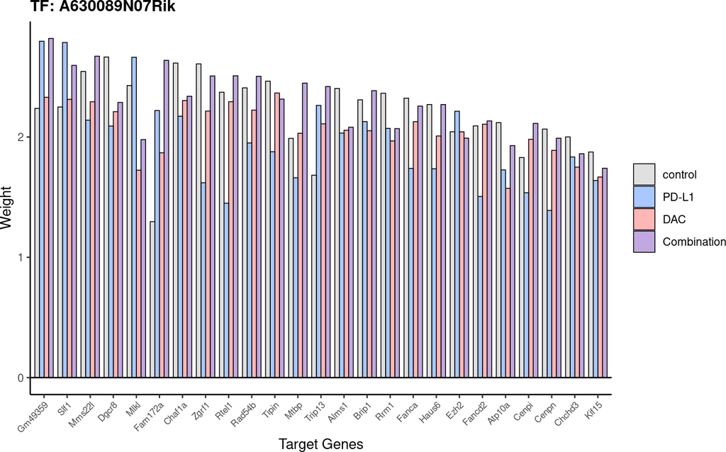

```r
all_tfs_barplots[[1]]
```

### 4.2.3 Regulatory Network Heatmap

You can extract a TF regulon with the function `get_tf_network` and plot in in heatmap fashion.

```r
network <- get_tf_network(simic_full, "Tet2", r2_threshold = 0.7)
print(head(network))
##           control    PD-L1      DAC Combination
## Brinp3  0.8540945 0.000000 0.000000    1.517455
## Slit2  -1.3650950 0.000000 0.000000          NA
## Top2a   0.0000000 0.000000 0.000000    0.000000
## Wls     0.0000000 0.000000 0.000000    0.000000
## Kif20b  0.0000000 0.000000 0.000000    0.000000
## Lamp2   1.2648960 1.633694 1.239646    1.140369
```

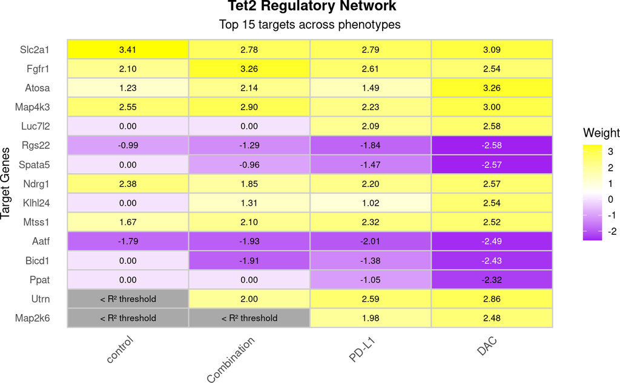

```r
plot_tf_network_heatmap(simic_full, "Tet2",
                        save = FALSE,
                        top_n = 15,
                        r2_threshold = 0.7,
                        show_values = T,
                        cmap = c("purple","white","yellow"))
## Warning in FUN(newX[, i], ...): no non-missing arguments to
## max; returning -Inf
## Warning in FUN(newX[, i], ...): no non-missing arguments to
## max; returning -Inf
## Warning in FUN(newX[, i], ...): no non-missing arguments to
## max; returning -Inf
## Warning in FUN(newX[, i], ...): no non-missing arguments to
## max; returning -Inf
```

# Dissimilarity Analysis

To prioritize those TFs of interest, that might be driving the regulatory differences between our groups we perform a dissimilarity analysis by comparing per-cell TF activity-score distributions across phenotype labels using the minmax version of total variation distance for multiple distributions. This metric has values between 0 and 1, with values closer to 0 when the group of distributions is more similar to each other. Consequently, higher scores indicate greater regulatory dissimilarity between conditions — i.e., TFs whose activity differs most across phenotypes.

## 4.3 Global dissimilarity scores

```r
dis_score <- calculate_dissimilarity(simic)
## Calculating dissimilarity scores (all cells)...
## Top 10 TFs by MinMax dissimilarity:
```

```r
top_tfs <- rownames(dis_score)
##               MinMax_score
## Ets1             0.6403333
## Zhx2             0.4236667
## Zfhx4            0.4063333
## A630089N07Rik    0.3853333
## Tet2             0.3666667
## Prrx2            0.3443333
## Crebrf           0.3400000
## Pbx3             0.3380000
## Gli3             0.3280000
## Pms1             0.3230000
```

## 4.4 Dissimilarity heatmap

We can visualize the top TFs ranked by dissimilarity score in a heatmap fashion.

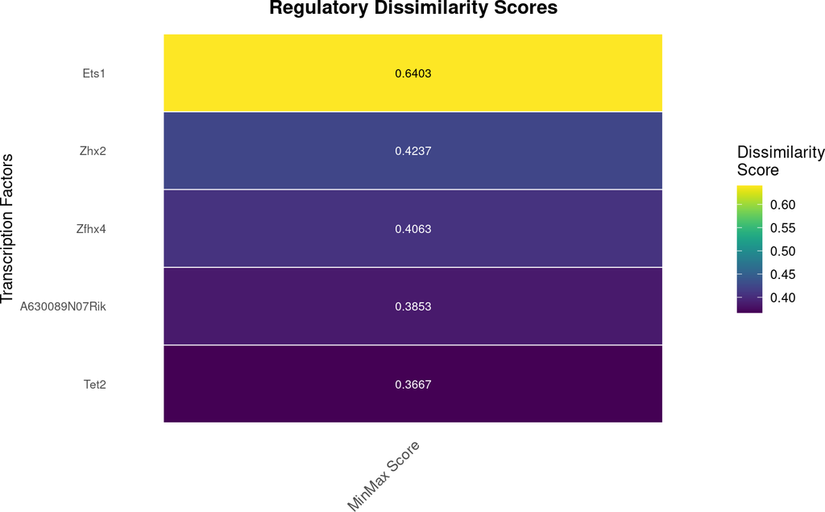

```r
plot_dissimilarity_heatmap(simic,
                           top_n = 5,
                           cmap = "viridis",
                           save = FALSE)
```

Sometimes these transcriptional dynamics are cell-type or cell-cluster specific. For that we might be interested in calculating the dissimilarity scores across the labels within specific cell clusters. For that, we can subset the `SimiCvizExperiment` object by the desired labels and then calculate the dissimilarity scores and plot the heatmap as shown before.

```r
metadata <- read.csv(system.file("extdata/metadata.csv",
  package = "SimiCviz"))

# Build cell groups from metadata (e.g. Seurat clusters, cell types, etc.)
cell_groups  <- lapply(unique(metadata$final_annotation_functional),
                       function(celltype) {
  cell_labels$cell[metadata$final_annotation_functional == celltype]
})
names(cell_groups) <- unique(metadata$final_annotation_functional)

dissim_grouped <- calculate_dissimilarity(simic, labels = c(0,2),
                                          cell_groups = cell_groups)
## Calculating dissimilarity for selected cell groups...
##   Group: Basal-like (1025 cells)
##   Group: Proliferating cells (475 cells)
## Top 10 TFs by mean dissimilarity across groups:
##               Basal.like Proliferating.cells mean_score
## Ets1           0.9241661           0.9863014  0.9552337
## Zhx2           0.7135425           0.8534696  0.7835060
## Zfhx4          0.6296566           0.8488098  0.7392332
## Pbx3           0.5492787           0.5179467  0.5336127
## Tet2           0.3127084           0.6451643  0.4789364
## A630089N07Rik  0.4466587           0.4925893  0.4696240
## Prrx2          0.3321819           0.4494536  0.3908177
## Pms1           0.2734957           0.4994386  0.3864671
## Gli3           0.3022958           0.3867992  0.3445475
## Crebrf         0.2720632           0.3109327  0.2914979
```

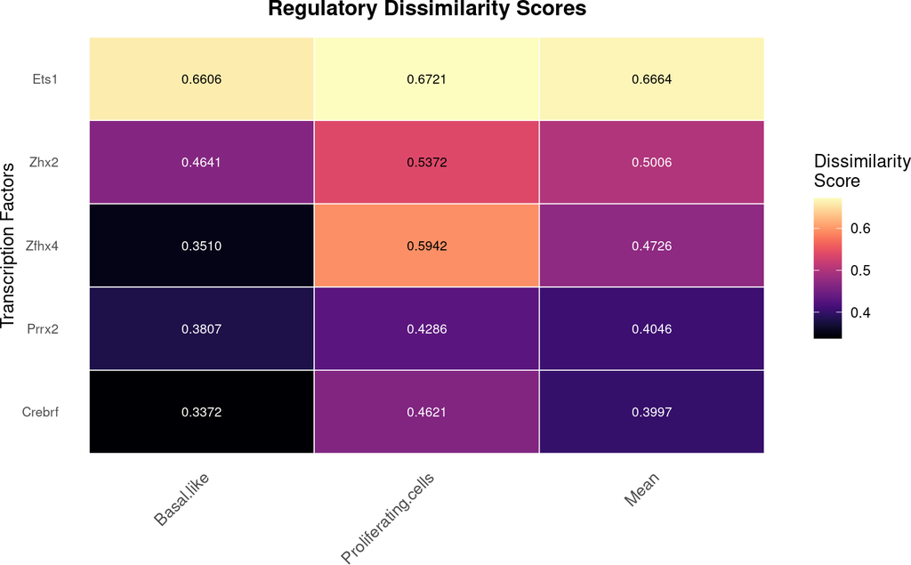

```r
# For all labels
plot_dissimilarity_heatmap(simic,
                            cell_groups = cell_groups,
                            top_n = 5,
                            cmap=c("magma"),
                            save = FALSE, out_dir = plot_dir,
                            filename = "dissimilarity_heatmap_grouped.pdf")
```

We can also select the labels accross which we want to compute the dissimilarity score with the argument `labels` and customize the color and sorting options.

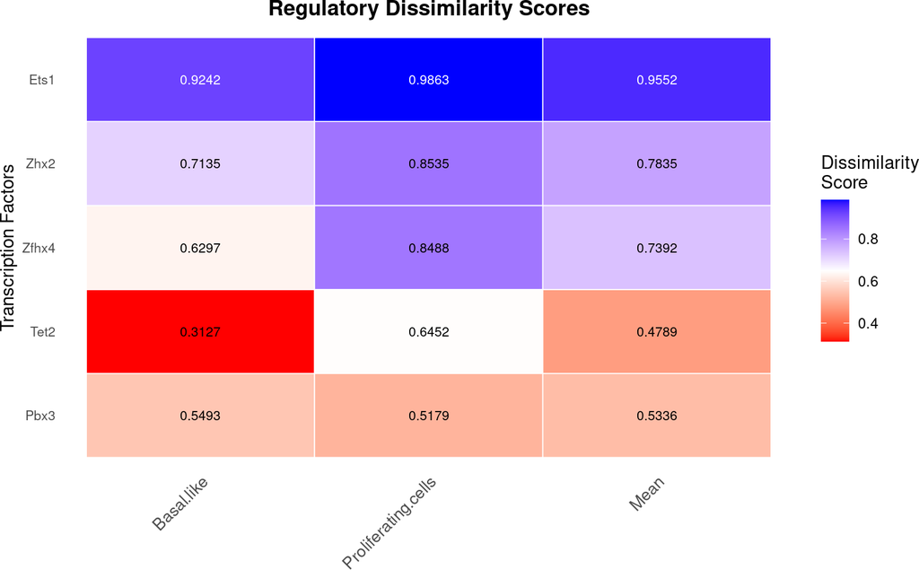

```r
# For labels 0,2
plot_dissimilarity_heatmap(simic,
                            labels = c(0,2),
                            cell_groups = cell_groups,
                            top_n = 5,
                            sort_by = "Proliferating.cells",
                            cmap=c("red", "white", "blue"),
                            save = FALSE)
```

# 5 Activity Score Distributions

Visualize TF activity distributions across conditions. These plots allow you to visually assess the differences in TF activity distributions across conditions, and can help identify TFs with distinct regulatory patterns that may be driving phenotypic differences.

### 5.0.1 Density plots

This function allows for customization of the plot aesthetics, including fill, transparency, bandwidth adjustment for density estimation, and rug plots to show individual data points. You can also choose to save the plots directly from the function.

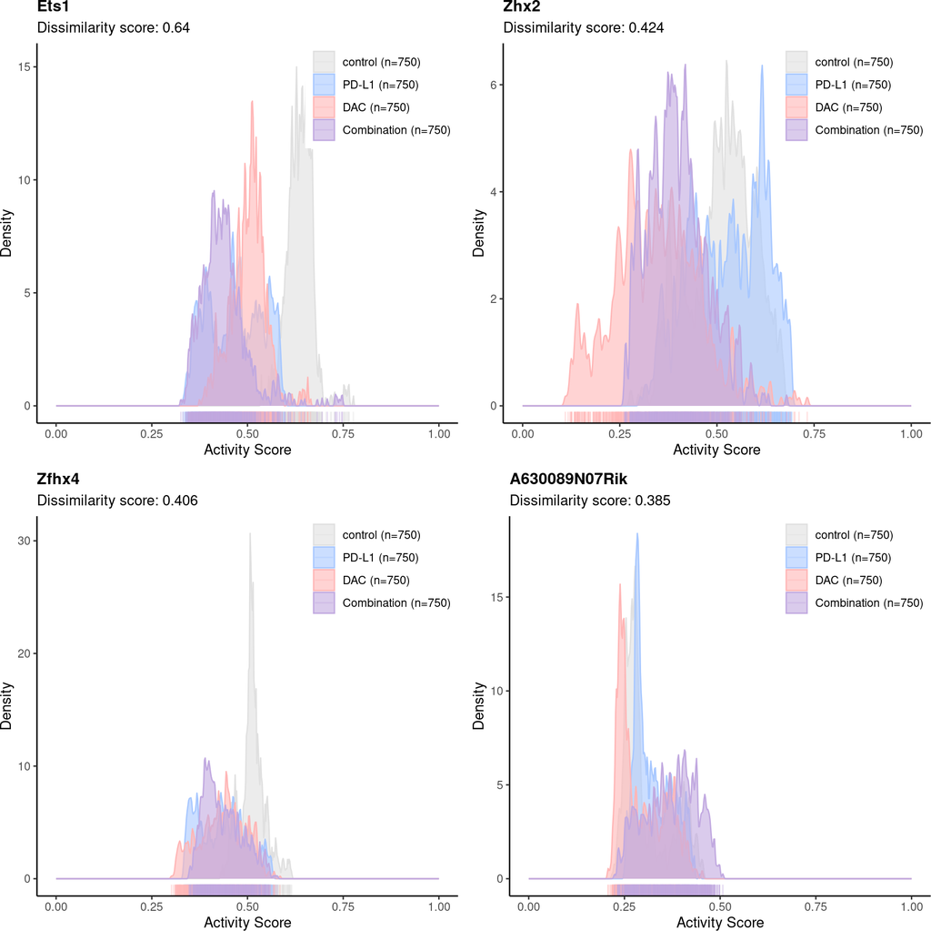

```r
# Plot distributions for top TFs
plot_auc_distributions(
  simic,
  tf_names = top_tfs[1:4],
  fill = TRUE,
  alpha = 0.6,
  bw_adjust = 1/8,
  rug = TRUE,
  save = FALSE,
  out_dir = plot_dir,
  filename = "AUC_distributions.pdf",
  grid = c(2, 2)
)
```

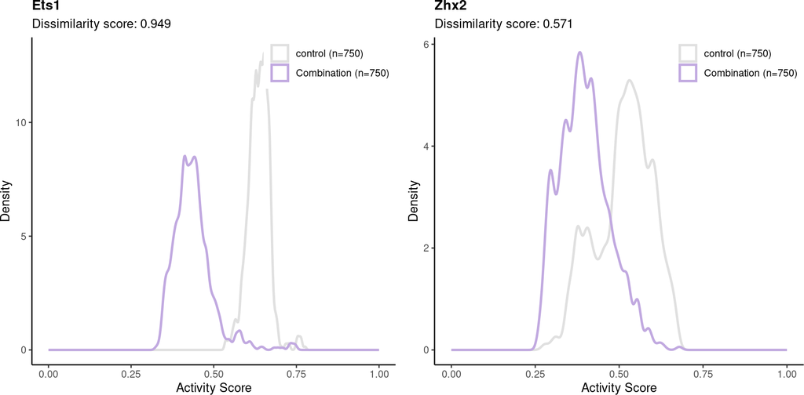

```r
# Plot top 4 TFs density distributions
plot_auc_distributions(simic,
                       labels = c(0,3),
                       tf_names = top_tfs[1:2],
                       fill = FALSE,
                       bw_adjust = 0.5,
                       rug = FALSE,
                       out_dir = plot_dir,
                       filename="AUC_distributions_notfilled_multipage.pdf",
                       save = FALSE,
                       grid = c(1,2))
```

### 5.0.2 Cumulative distributions (ECDF)

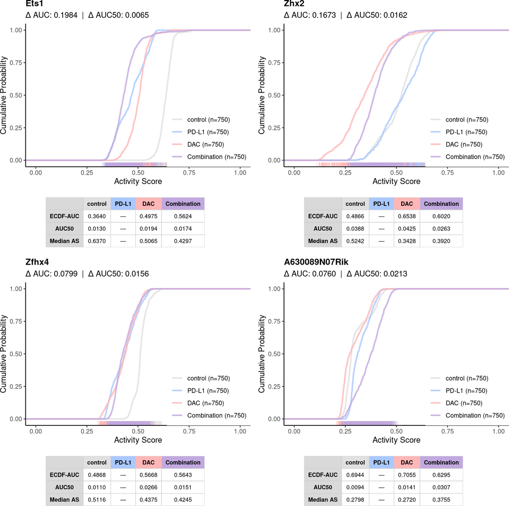

## 5.1 ECDF-based Metrics

Compute area-under-curve metrics from ECDF comparisons:

```r
ecdf_metrics <- calculate_ecdf_auc(simic, tf_names = simic@tf_ids[1:4])
head(ecdf_metrics)
##       control_ecdf_auc control_auc50 control_x_at_p50
## Pms1         0.6533507    0.01569645        0.3132663
## Prrx2        0.4984653    0.05676584        0.5112166
## Ets1         0.3640433    0.01295403        0.6369586
## Tet2         0.5568117    0.02646118        0.4543279
##       PD.L1_ecdf_auc PD.L1_auc50 PD.L1_x_at_p50
## Pms1       0.6603952  0.02314261      0.3046211
## Prrx2      0.6369034  0.04873111      0.3443356
## Ets1       0.5320270  0.03060067      0.4690785
## Tet2       0.5519579  0.02374385      0.4524892
##       DAC_ecdf_auc  DAC_auc50 DAC_x_at_p50
## Pms1     0.6829972 0.01867141    0.3033446
## Prrx2    0.5751205 0.03807905    0.4045226
## Ets1     0.4975414 0.01944998    0.5065387
## Tet2     0.5659048 0.01265059    0.4341352
##       Combination_ecdf_auc Combination_auc50
## Pms1             0.6029903        0.03091298
## Prrx2            0.6079563        0.04226830
## Ets1             0.5624084        0.01740813
## Tet2             0.5930339        0.01583255
##       Combination_x_at_p50 delta_ecdf_auc delta_auc50
## Pms1             0.3987754     0.08000684 0.015216527
## Prrx2            0.3350724     0.10949101 0.018686787
## Ets1             0.4297028     0.19836509 0.006495945
## Tet2             0.3864523     0.03622227 0.013810585
##       delta_x_at_p50
## Pms1      0.09543084
## Prrx2     0.17614425
## Ets1      0.20725580
## Tet2      0.06787563
```

## 5.2 Summary Statistics

### 5.2.1 Mean activity per TF × phenotype

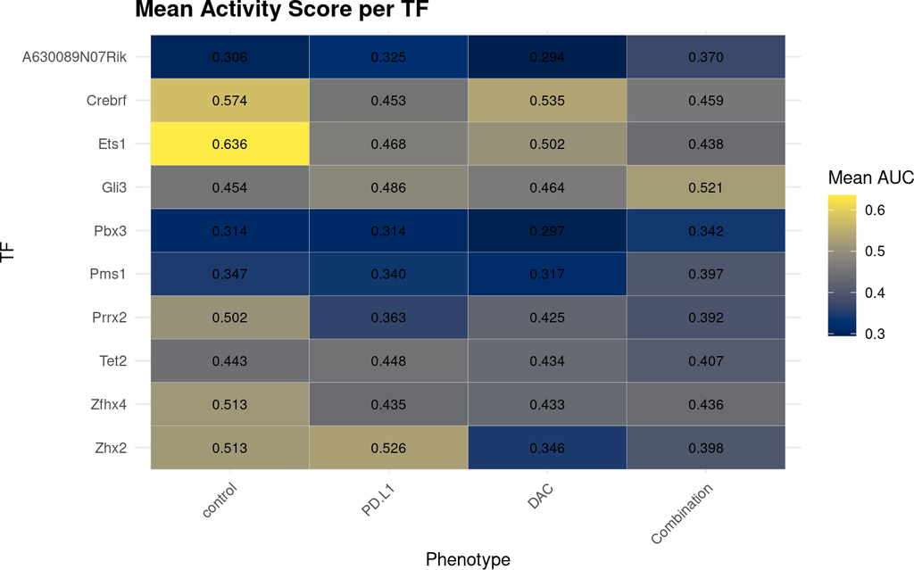

```r
plot_auc_heatmap(simic, top_n = 20)
```

### 5.2.2 Box plots and violin plots

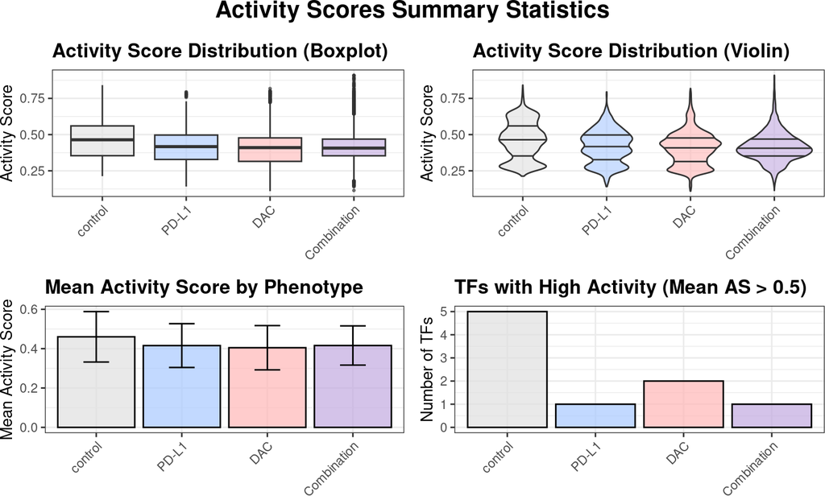

```r
summary_plot <- plot_auc_summary_statistics(simic)
```

# 6 Session Info

```r
sessionInfo()
## R version 4.4.0 (2024-04-24)
## Platform: x86_64-pc-linux-gnu
## Running under: Ubuntu 22.04.4 LTS
##
## Matrix products: default
## BLAS:   /usr/lib/x86_64-linux-gnu/openblas-pthread/libblas.so.3
## LAPACK: /usr/lib/x86_64-linux-gnu/openblas-pthread/libopenblasp-r0.3.20.so;  LAPACK version 3.10.0
##
## locale:
##  [1] LC_CTYPE=en_US.UTF-8       LC_NUMERIC=C
##  [3] LC_TIME=en_US.UTF-8        LC_COLLATE=C
##  [5] LC_MONETARY=en_US.UTF-8    LC_MESSAGES=en_US.UTF-8
##  [7] LC_PAPER=en_US.UTF-8       LC_NAME=C
##  [9] LC_ADDRESS=C               LC_TELEPHONE=C
## [11] LC_MEASUREMENT=en_US.UTF-8 LC_IDENTIFICATION=C
##
## time zone: Etc/UTC
## tzcode source: system (glibc)
##
## attached base packages:
## [1] stats     graphics  grDevices utils     datasets
## [6] methods   base
##
## other attached packages:
## [1] BiocStyle_2.34.0 SimiCviz_0.1.0
##
## loaded via a namespace (and not attached):
##   [1] gridExtra_2.3
##   [2] remotes_2.5.0
##   [3] rlang_1.1.4
##   [4] magrittr_2.0.3
##   [5] matrixStats_1.5.0
##   [6] compiler_4.4.0
##   [7] roxygen2_7.3.1
##   [8] png_0.1-8
##   [9] vctrs_0.6.5
##  [10] reshape2_1.4.4
##  [11] stringr_1.5.1
##  [12] profvis_0.3.8
##  [13] pkgconfig_2.0.3
##  [14] crayon_1.5.2
##  [15] fastmap_1.2.0
##  [16] magick_2.8.3
##  [17] XVector_0.46.0
##  [18] ellipsis_0.3.2
##  [19] labeling_0.4.3
##  [20] utf8_1.2.4
##  [21] promises_1.3.0
##  [22] rmarkdown_2.27
##  [23] sessioninfo_1.2.2
##  [24] UCSC.utils_1.2.0
##  [25] tinytex_0.51
##  [26] purrr_1.0.2
##  [27] xfun_0.44
##  [28] zlibbioc_1.52.0
##  [29] cachem_1.1.0
##  [30] GenomeInfoDb_1.42.1
##  [31] jsonlite_1.8.8
##  [32] highr_0.11
##  [33] later_1.3.2
##  [34] DelayedArray_0.32.0
##  [35] BiocParallel_1.40.0
##  [36] parallel_4.4.0
##  [37] R6_2.5.1
##  [38] bslib_0.7.0
##  [39] stringi_1.8.4
##  [40] reticulate_1.45.0
##  [41] pkgload_1.3.4
##  [42] GenomicRanges_1.58.0
##  [43] jquerylib_0.1.4
##  [44] Rcpp_1.0.12
##  [45] bookdown_0.39
##  [46] SummarizedExperiment_1.36.0
##  [47] knitr_1.47
##  [48] snow_0.4-4
##  [49] usethis_2.2.3
##  [50] IRanges_2.40.1
##  [51] httpuv_1.6.15
##  [52] Matrix_1.7-0
##  [53] tidyselect_1.2.1
##  [54] rstudioapi_0.16.0
##  [55] abind_1.4-5
##  [56] yaml_2.3.8
##  [57] codetools_0.2-20
##  [58] miniUI_0.1.1.1
##  [59] pkgbuild_1.4.4
##  [60] lattice_0.22-6
##  [61] tibble_3.2.1
##  [62] plyr_1.8.9
##  [63] Biobase_2.66.0
##  [64] shiny_1.8.1.1
##  [65] withr_3.0.0
##  [66] evaluate_0.24.0
##  [67] desc_1.4.3
##  [68] urlchecker_1.0.1
##  [69] xml2_1.3.6
##  [70] pillar_1.9.0
##  [71] BiocManager_1.30.23
##  [72] MatrixGenerics_1.18.1
##  [73] stats4_4.4.0
##  [74] generics_0.1.3
##  [75] rprojroot_2.0.4
##  [76] S4Vectors_0.44.0
##  [77] ggplot2_3.5.1
##  [78] munsell_0.5.1
##  [79] commonmark_1.9.1
##  [80] scales_1.3.0
##  [81] xtable_1.8-4
##  [82] glue_1.7.0
##  [83] tools_4.4.0
##  [84] fs_1.6.4
##  [85] grid_4.4.0
##  [86] tidyr_1.3.1
##  [87] devtools_2.4.5
##  [88] colorspace_2.1-0
##  [89] GenomeInfoDbData_1.2.13
##  [90] cli_3.6.2
##  [91] fansi_1.0.6
##  [92] S4Arrays_1.6.0
##  [93] viridisLite_0.4.2
##  [94] dplyr_1.1.4
##  [95] gtable_0.3.5
##  [96] sass_0.4.9
##  [97] digest_0.6.35
##  [98] BiocGenerics_0.52.0
##  [99] SparseArray_1.6.0
## [100] farver_2.1.2
## [101] htmlwidgets_1.6.4
## [102] memoise_2.0.1
## [103] htmltools_0.5.8.1
## [104] lifecycle_1.0.4
## [105] httr_1.4.7
## [106] mime_0.12
```